# Homework 8

Solutions

# Preliminaries

- This file should be in `STAT240/homework/hw08` on your local computer.
- Download `superbowl_commercials.csv` to `STAT240/data`.

# Problem 1

Let $X \sim Binom(5, 0.4)$.

1. Use `dbinom()` to calculate the full pmf of $X$. You should have a vector of length 6 that adds up to 1. Then, use `geom_col()` to plot the pmf of $X$.

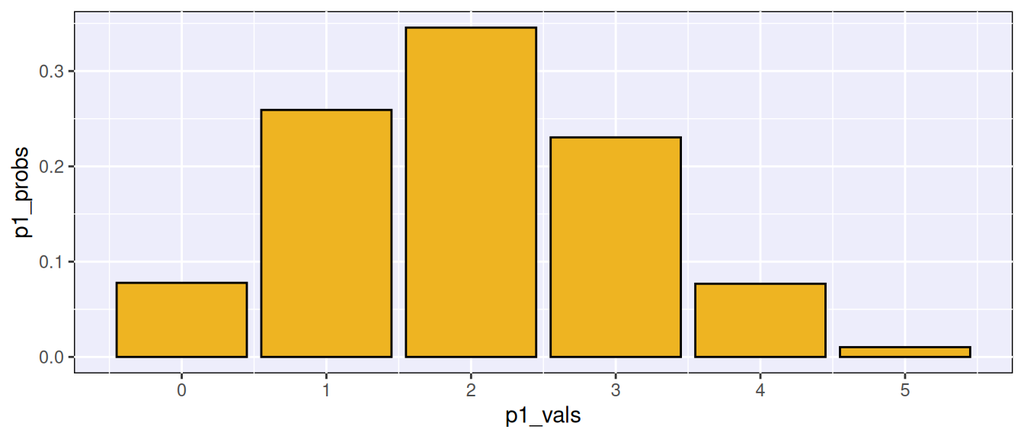

```r
p1_vals <- 0:5
p1_probs <- dbinom(0:5, 5, 0.4)

ggplot(mapping = aes(x = p1_vals, y = p1_probs)) +
  geom_col(color = "black", fill = "goldenrod2") +
  scale_x_continuous(breaks = 0:5)
```

2. What are $E(X)$, $V(X)$, and $sd(X)$ using the binomial shortcut formulas?

$$E(X) \;=\; np \;=\;
5(0.4) \;=\; 2$$

$$V(X) \;=\; np(1-p)
\;=\; 5(0.4)(0.6) \;=\; 1.2$$

3. Check your answers to (b) by re-calculating $E(X)$, $V(X)$, and $sd(X)$ with the generic discrete formulas described at the end of the chapter 8 notes. Ensure that your results in (b) and (c) match.

```r
# General expected value formula
x_mean = sum(p1_vals*p1_probs)

# General variance formula
x_var = sum( (p1_vals - x_mean)^2 * p1_probs )

x_sd = sqrt(x_var)

x_mean; x_var; x_sd
```

```
## [1] 2
```

```
## [1] 1.2
```

```
## [1] 1.095445
```

The results match the values calculated from the binomial shortcuts.

# Problem 2

Let $X \sim Binom(400, 0.3)$ and let the sample proportion $\hat{p}$ be $X/n$. Consider two ways to estimate the distribution of $\hat{p}$: simulation, and a normal approximation.

1. Perform a simulation of 10000 different instances of $\hat{p}$. You should use the `relicate()` function and you can use `sample(0:1, ...)` to represent drawing from a binary population. Plot the results of your samples in a histogram and comment on the shape.

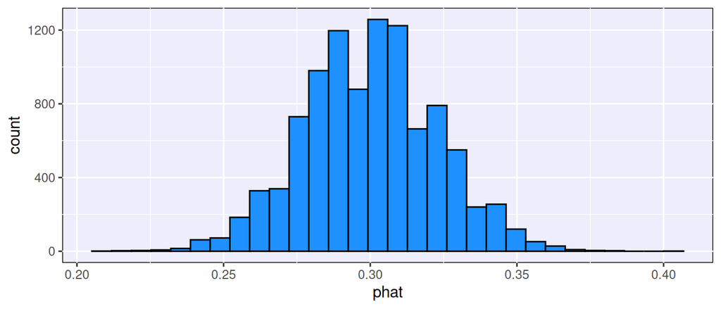

```r
set.seed(240)

sample_phats <- tibble(
  phat = replicate(10000,
                   mean(sample(0:1, size = 400,
                               replace = T, prob = c(0.7, 0.3))))
)

ggplot(sample_phats, aes(x = phat)) +
  geom_histogram(color = "black", fill = "dodgerblue")
```

The histogram of resamples has an approximate normal bell-curve shape that is centered at 0.3 and has a standard deviation of about 0.02 (based on a visual approximation).

2. What is the theoretical sampling distribution of $\hat{p}$ using a normal approximation? Does this match the shape of the graph in (a)?

Under the normal approximation, the sampling distribution of $\hat{p}$ is given by
$$\hat{p} \;\dot{\sim}\; N\Big(0.3,
\sqrt{\frac{0.3(1-0.3)}{400}}\Big) \;=\; N(0.3, 0.0229)$$
This matches the shape shown in the histogram of the empirical samples.

3. Find $P(\hat{p} \le 0.31)$ with the simulated $\hat{p}$’s as well as with the theoretical normal distribution. Are the results consistent?

```r
# Simulation:
mean(sample_phats$phat <= 0.31)
```

```
## [1] 0.6913
```

```r
# Normal approximation:
pnorm(0.31, 0.3, 0.0229)
```

```
## [1] 0.6688287
```

The simulated probability is 0.691 and the normal approximation is 0.669. The values are fairly similar to each other.

4. Find the 20th percentile of $\hat{p}$ with the simulated $\hat{p}$’s as well as with the theoretical normal distribution. Are the results consistent?

```r
# Simulation:
quantile(sample_phats$phat, 0.2)
```

```
##  20%
## 0.28
```

```r
# Normal approximation:
qnorm(0.2, 0.3, 0.0229)
```

```
## [1] 0.2807269
```

The simulated 20th percentile is 0.28 and the normal approximation of the 20th percentile is 0.281. The values are fairly similar to each other.

# Problem 3

We wish to test whether 75% of UW-Madison students drink caffeine by taking a random sample of 80 students.

$$H_0: p = 0.75 \quad \text{versus} \quad
H_A: p \neq 0.75$$

We’ll use significance level $\alpha=0.05$. Our standard error is

$$\sqrt{\frac{0.75(1-0.75)}{80}} \;=\;
0.0484$$

which means the test statistic is given by

$$Z \;=\; \frac{\hat{p} -
0.75}{0.0484}$$

1. After completing our survey, we will measure some observed $\hat{p}$, and use that to get $z_{obs}$, our test statistic. Find the rejection threshold for our test. In other words, what values of $z_{obs}$ on the $N(0, 1)$ null distribution would result in a two-sided p-value less than 0.05?

We are calculating a two-sided p-value, which is 2x the tail area of our Z test statistic. That means the area outside of a single tail just be less than 0.025. This happens if our Z test statistic is less than the 2.5 percentile or greater than the 97.5 percentile.

```r
lower_reject_threshold <- qnorm(0.025)
upper_reject_threshold <- qnorm(0.975)

lower_reject_threshold; upper_reject_threshold
```

```
## [1] -1.959964
```

```
## [1] 1.959964
```

We reject the null if we get a Z-score less than -1.96 or greater than 1.96. These are the same as the critical values for a 95% CI.

2. What values of $\hat{p}$ would result in a two-sided p-value less than 0.05, thus rejecting the null? (Take your work from (a), and solve for $\hat{p}$).

If we plug in our Z test statistic to the lower threshold we found, we get
$$\frac{\hat{p} -
0.75}{0.0484} \le -1.96 \quad \Rightarrow \quad \hat{p} \le
-1.96(0.0484) + 0.75 \quad \Rightarrow \quad \hat{p} \le 0.655.$$
A similar calculation for the upper threshold gives us
$$\frac{\hat{p} - 0.75}{0.0484} \ge 1.96 \quad
\Rightarrow \quad \hat{p} \ge 1.96(0.0484) + 0.75 \quad \Rightarrow
\quad \hat{p} \le 0.845.$$
So, if we observe a $\hat{p}$ less than 0.655 or greater than 0.845, that’s far enough away from 0.75 that we would end up rejecting the null.

3. Suppose the true $p = 0.85$. Based on what you found in (b), what is the probability that we reject $H_0$ from our sample of 80? You’ll need to use the sampling distribution of $\hat{p}$ with $p = 0.85$.

If the true $p = 0.85$, the sampling distribution of $\hat{p}$ is approximately
$$N\Big(0.85, \sqrt{\frac{0.85(1-0.85)}{80}}\Big)
\;=\; N(0.85, 0.04).$$
So, we need to find the probability of getting draw less than 0.655 or greater than 0.845 on this normal curve.

```r
pnorm(0.655, 0.85, 0.04) +
  pnorm(0.845, 0.85, 0.04, lower.tail = F)
```

```
## [1] 0.5497388
```

4. The probability calculated in (c) is the “true positive rate”, called **power**. If we decrease $\alpha$ to 0.01, will the power increase or decrease? How can you tell without having to re-calculate the power?

The power will decrease. If we have a smaller $\alpha$, the space to reject the null hypothesis will be smaller. The new lower bound on $\hat{p}$ will be less than 0.655 and the new upper bound on $\hat{p}$ will be greater than 0.845.

# Problem 4

The file `superbowl_commercials.csv` contains a list of advertisements for 10 brands aired during Super Bowls from 2000 to 2020. Each advertisement is classified according to several characterisitcs. More information can be found [here](https://github.com/fivethirtyeight/superbowl-ads).

Transform the data as follows:

- Group the rows by brand
- Count the number of ads described as “Funny”
- Count the total number of ads
- Find the proportion of “Funny” ads for each brand
- Save the dataset to your environment for the later problems
- Print the dataset so it is visible in the knitted .html

```r
commercials <- read_csv("../../data/superbowl_commercials.csv")
```

```r
commercials_tidy <- commercials %>%
  group_by(Brand) %>%
  summarize(n_funny = sum(Funny), n_tot = n()) %>%
  mutate(p_funny = n_funny/n_tot)

commercials_tidy
```

```
## # A tibble: 10 × 4
##    Brand     n_funny n_tot p_funny
##    <chr>       <int> <int>   <dbl>
##  1 Bud Light      59    62   0.952
##  2 Budweiser      21    43   0.488
##  3 Coca-Cola       8    21   0.381
##  4 Doritos        25    26   0.962
##  5 E-Trade        13    14   0.929
##  6 Hyundai        12    22   0.545
##  7 Kia             8    13   0.615
##  8 NFL             2    11   0.182
##  9 Pepsi          18    25   0.72
## 10 Toyota          6    12   0.5
```

# Problem 5

```r
# Total number of ads (number of rows of original data)
n <- sum(commercials_tidy$n_tot)

# Number of funny ads
x <- sum(commercials_tidy$n_funny)

phat <- x / n

# Proportion tandard error
se <- sqrt(phat*(1 - phat)/n)

# Critical value for 99% confidence
cv <- qnorm(0.995)

# Find upper and lower bounds of interval
c(phat - cv*se, phat + cv*se)
```

```
## [1] 0.6153185 0.7662076
```

Our point estimate for the proportion of funny ads is 0.691. This gives a standard error of about 0.029. Finally, the Z critical value for 99% confidence is $z_{0.005} = 2.576$.

```r
# Find upper and lower bounds of interval
c(phat - cv*se, phat + cv*se)
```

```
## [1] 0.6153185 0.7662076
```

We are 99% confident that the true proportion of funny advertisements is within (0.616, 0.766).

# Problem 6

Perform a Z hypothesis test to determine whether half of superbowl ads are funny. Use hyoptheses
$$H_0:
p_{funny} = 0.5 \quad \text{versus}\quad H_A: p_{funny} \neq
0.5$$
and $\alpha = 0.01$. Interpret your result in context.

Our observed test statistic based on $p_0 = 0.5$ is
$$z_{obs} \;=\; \frac{0.691 -
0.5}{\sqrt{\frac{0.5(0.5)}{249}}} \;=\; 6.028$$

```r
# R calculation of test stat and p-value
# Total number of ads (number of rows of original data)
n <- sum(commercials_tidy$n_tot)

# Number of funny ads
x <- sum(commercials_tidy$n_funny)

phat <- x / n

# Proportion standard error assuming p0 = 0.5
se <- sqrt(0.5*(1 - 0.5)/n)

test_stat <- (phat - 0.5) / se

# Two-sided p-value calculation
2*pnorm(test_stat, lower.tail = F)
```

```
## [1] 1.740077e-09
```

If one-half of advertisements are funny, the proability of seeing our observed data or something more extreme is very small. Our p-value is much smaller than $\alpha = 0.01$, so we reject $H_0$. We have evidence that more than half of ads are funny.

# Problem 7

State the model and assumptions you used to perform inference on $p_{funny}$ in problems 5 and 6. State one criticism where reality may differ from the assumptions, potentially leading to misleading conclusions.

The null distribution in the Z hypothesis test and the Z CI both use a normal approximation of a binomial process. There are no concerns about this, since $n$ is large and $n\hat{p}(1-\hat{p}) = 249(0.691)(1-0.691) = 53.2$ is more than large enough for the normal approximation to be valid.

However, there may be some concerns with whether the underlying process is binomial. We are assuming that the count of funny ads is binomial with $n = 249$ and some success probability $p$.

These assumptions rely on the BINS assumptions, but I am skeptical about the “S” or same probability assumption. The $n = 249$ counts the ads across 10 different companies, and different companies might be more or less likely to advertise their product with humor.

# Problem 8

Compare the results of the confidence interval in 5 with the hypothesis test in 6.

1. Do both methods agree on whether or not $p = 0.5$ is reasonable for the proportion of funny superbowl ads?

Both methods are consistent since they both reject 0.5 as a reasonable guess for the true $p$. The hypothesis test resulted in a very small p-value, which corresponds to strong evidence against $H_0: p = 0.5$. Meanwhile, the confidence interval does not cover the value 0.5, meaning we can be at least 99% confident that the true $p$ is not 0.5.

2. Is it *always* the case that a proportion Z test and a proportion Z CI will give the same result based on the same null value? Briefly explain why or why not. (Consider comparing the formulas for a CI and a test statistic).

The two methods will often agree with each other, especially if there is a highly significant result or a highly non-significant result. However, the two methods are not equal to each other because the standard error terms are different. In hypothesis testing, the SE is calculated based on the null value of p, giving
$$\sqrt{\frac{0.5(1-0.5)}{249}}.$$
When building a confidence interval, the SE is estimated from the observed proportion, giving
$$\sqrt{\frac{0.691(1-0.691)}{249}}.$$
If we used the latter SE term when doing a hypothesis test, it would be identical to the CI we made.